# Model Building

## Agenda

## Exploration vs confirmation

- Each observation can either be used for exploration or confirmation, not both.
- You can use an observation as many times as you like for exploration, but you can only use it once for confirmation.
- As soon as you use an observation twice, you’ve switched from confirmation to exploration.

## Splitting data

Wickham recommends splitting your data into three pieces before you begin the analysis:

- 60% of your data goes into a training (or exploration) set. You’re allowed to do anything you like with this data: visualise it and fit tons of models to it.
- 20% goes into a query set. You can use this data to compare models or visualisations by hand, but you’re not allowed to use it as part of an automated process.
- 20% is held back for a test set. You can only use this data ONCE, to test your final model.

## Modeling process

- Choose a family of models (e.g., straight line, quadratic curve)
- Generate a fitted model – this represents the “best” model of your chosen family of models (and that’s it, actually…)

## modelr

```r
library(tidyverse)
library(modelr) #wrapper for models, works with pipe
options(na.action = na.warn)
```

## A simple relationship

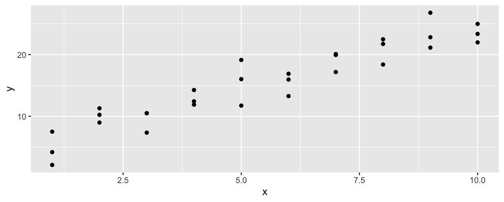

```r
#sim1 part of the modelr package
ggplot(sim1, aes(x, y)) +
  geom_point()
```

## Trying models

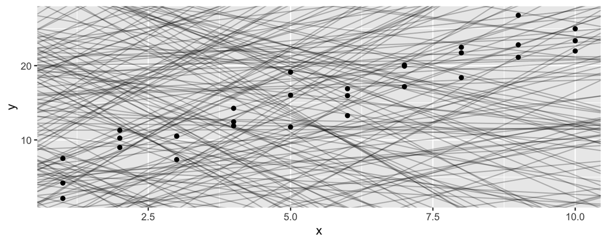

```r
models <- tibble(
  a1 = runif(250, -20, 40),
  a2 = runif(250, -5, 5)
)
ggplot(sim1, aes(x, y)) +
  geom_abline(aes(intercept = a1, slope = a2), data = models, alpha = 1/4) +
  geom_point()
```

## Distance (residual)

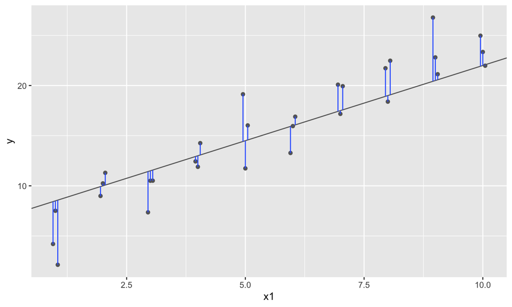

## Predicted values

Turn the model family into a function:

```r
model1 <- function(a, data) {
  a[1] + data$x * a[2]
}
model1(c(7, 1.5), sim1)
```

```
##  [1]  8.5  8.5  8.5 10.0 10.0 10.0 11.5 11.5 11.5 13.0 13.0 13.0 14.5 14.5
## [15] 14.5 16.0 16.0 16.0 17.5 17.5 17.5 19.0 19.0 19.0 20.5 20.5 20.5 22.0
## [29] 22.0 22.0
```

## RMSD (RMSE)

Compute the difference between actual and predicted, square them, average them, and the take the square root.

```r
measure_distance <- function(mod, data) {
  diff <- data$y - model1(mod, data)
  sqrt(mean(diff ^ 2))
}
measure_distance(c(7, 1.5), sim1)
```

```
## [1] 2.665212
```

## Multiple models

```r
sim1_dist <- function(a1, a2) {
  measure_distance(c(a1, a2), sim1)
}

models <- models %>%
  mutate(dist = purrr::map2_dbl(a1, a2, sim1_dist))
models
```

```
## # A tibble: 250 x 3
##        a1     a2  dist
##     <dbl>  <dbl> <dbl>
##  1  20.9   3.73  26.5
##  2  34.3  -1.94  14.2
##  3 -16.4   1.81  22.1
##  4  15.9   0.265  5.87
##  5  25.6  -4.49  23.9
##  6  -6.79 -3.12  42.2
##  7  -6.72 -3.38  43.8
##  8  33.0   3.96  39.7
##  9  20.3  -3.66  22.5
## 10  22.5  -0.125  9.12
## # … with 240 more rows
```

## 10 best models

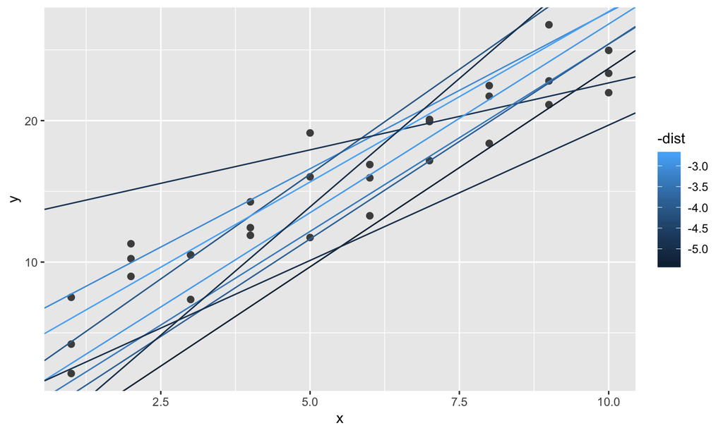

## Models as observations

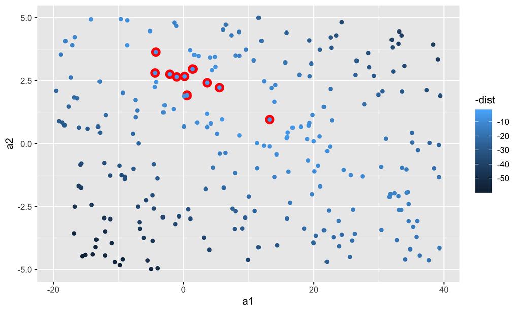

```r
ggplot(models, aes(a1, a2)) +
  geom_point(data = filter(models, rank(dist) <= 10), size = 4, colour = "red") +
  geom_point(aes(colour = -dist))
```

## Grid search

```r
grid <- expand.grid(
  a1 = seq(-5, 20, length = 25),
  a2 = seq(1, 3, length = 25)
  ) %>%
  mutate(dist = purrr::map2_dbl(a1, a2, sim1_dist))

grid %>%
  ggplot(aes(a1, a2)) +
  geom_point(data = filter(grid, rank(dist) <= 10), size = 4, colour = "red") +
  geom_point(aes(colour = -dist))
```

## Grid search

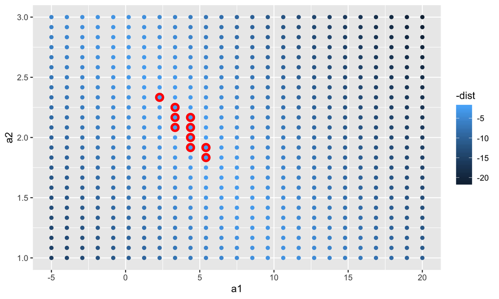

## Grid search

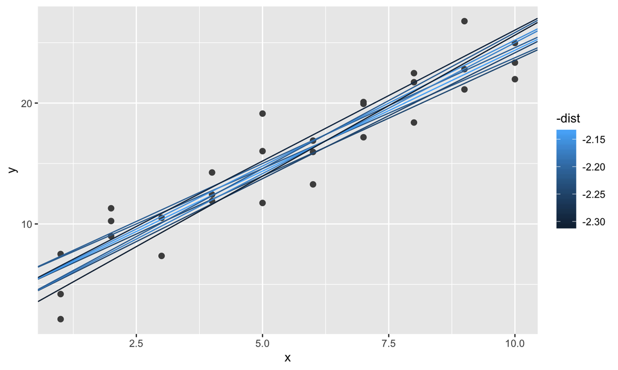

## Basic optimization

```r
#Newton-Raphson optimization
best <- optim(c(0, 0), measure_distance, data = sim1)
best$par
```

```
## [1] 4.222248 2.051204
```

## Basic optimization

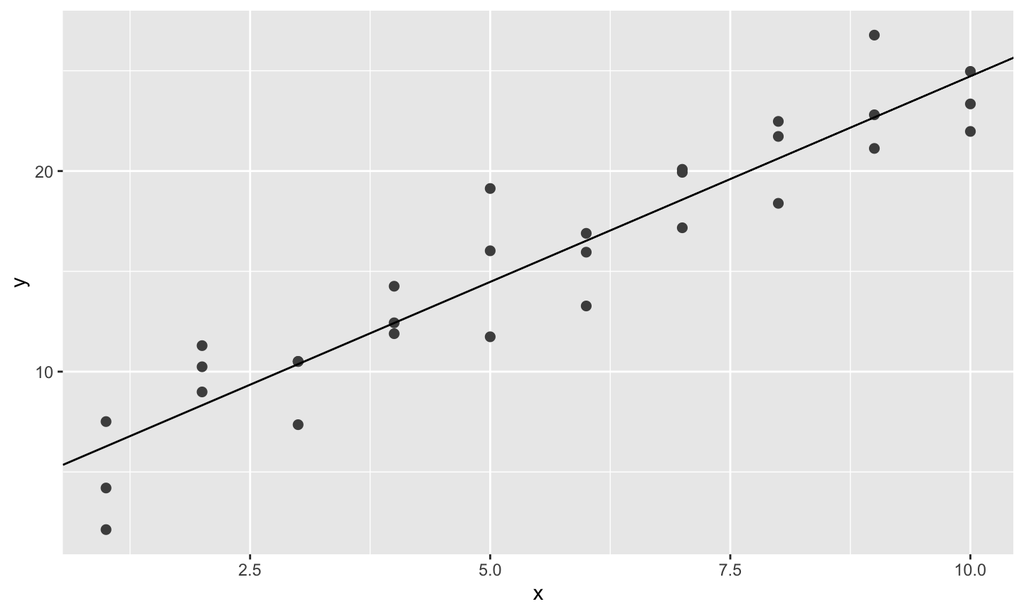

## lm

```r
sim1_mod <- lm(y ~ x, data = sim1)
coef(sim1_mod)
```

```
## (Intercept)           x
##    4.220822    2.051533
```

`lm` doesn’t actually use `optim` – it uses properties you see in STAT 542

## Many models

```r
library(gapminder)
gapminder
```

```
## # A tibble: 1,704 x 6
##    country     continent  year lifeExp      pop gdpPercap
##    <fct>       <fct>     <int>   <dbl>    <int>     <dbl>
##  1 Afghanistan Asia       1952    28.8  8425333      779.
##  2 Afghanistan Asia       1957    30.3  9240934      821.
##  3 Afghanistan Asia       1962    32.0 10267083      853.
##  4 Afghanistan Asia       1967    34.0 11537966      836.
##  5 Afghanistan Asia       1972    36.1 13079460      740.
##  6 Afghanistan Asia       1977    38.4 14880372      786.
##  7 Afghanistan Asia       1982    39.9 12881816      978.
##  8 Afghanistan Asia       1987    40.8 13867957      852.
##  9 Afghanistan Asia       1992    41.7 16317921      649.
## 10 Afghanistan Asia       1997    41.8 22227415      635.
## # … with 1,694 more rows
```

## Motivating question

How does life expectancy (`lifeExp`) change over time (`year`) for each country (`country`)?

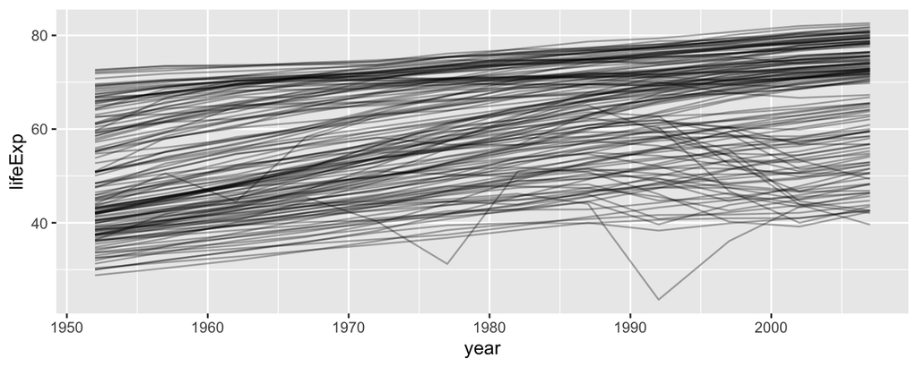

```r
gapminder %>%
  ggplot(aes(year, lifeExp, group = country)) +
    geom_line(alpha = 1/3)
```

## New Zealand

- `add_predictions()` creates `pred` given a model, and
- `add_residuals()` creates `resid` based on the model

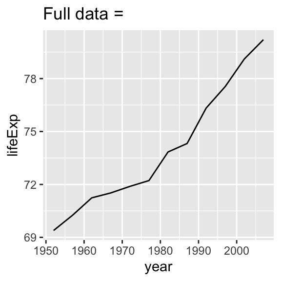

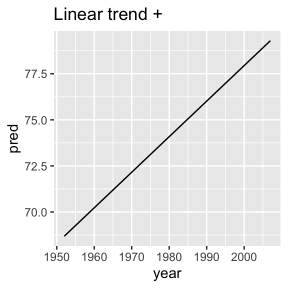

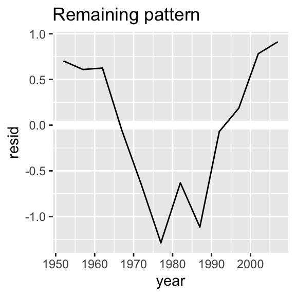

## Nested data

```r
by_country <- gapminder %>%
  group_by(country, continent) %>%
  nest()
by_country
```

```
## # A tibble: 142 x 3
## # Groups:   country, continent [710]
##    country     continent           data
##    <fct>       <fct>     <list<df[,4]>>
##  1 Afghanistan Asia            [12 × 4]
##  2 Albania     Europe          [12 × 4]
##  3 Algeria     Africa          [12 × 4]
##  4 Angola      Africa          [12 × 4]
##  5 Argentina   Americas        [12 × 4]
##  6 Australia   Oceania         [12 × 4]
##  7 Austria     Europe          [12 × 4]
##  8 Bahrain     Asia            [12 × 4]
##  9 Bangladesh  Asia            [12 × 4]
## 10 Belgium     Europe          [12 × 4]
## # … with 132 more rows
```

## Nested data

```r
by_country$data[[1]]
```

```
## # A tibble: 12 x 4
##     year lifeExp      pop gdpPercap
##    <int>   <dbl>    <int>     <dbl>
##  1  1952    28.8  8425333      779.
##  2  1957    30.3  9240934      821.
##  3  1962    32.0 10267083      853.
##  4  1967    34.0 11537966      836.
##  5  1972    36.1 13079460      740.
##  6  1977    38.4 14880372      786.
##  7  1982    39.9 12881816      978.
##  8  1987    40.8 13867957      852.
##  9  1992    41.7 16317921      649.
## 10  1997    41.8 22227415      635.
## 11  2002    42.1 25268405      727.
## 12  2007    43.8 31889923      975.
```

## Extending to all countries

```r
country_model <- function(df) {
  lm(lifeExp ~ year, data = df)
}
```

```r
by_country <- by_country %>%
  mutate(model = map(data, country_model)) %>%
  mutate(resids = map2(data, model, add_residuals))
by_country
```

```
## # A tibble: 142 x 5
## # Groups:   country, continent [710]
##    country     continent           data model  resids
##    <fct>       <fct>     <list<df[,4]>> <list> <list>
##  1 Afghanistan Asia            [12 × 4] <lm>   <tibble [12 × 5]>
##  2 Albania     Europe          [12 × 4] <lm>   <tibble [12 × 5]>
##  3 Algeria     Africa          [12 × 4] <lm>   <tibble [12 × 5]>
##  4 Angola      Africa          [12 × 4] <lm>   <tibble [12 × 5]>
##  5 Argentina   Americas        [12 × 4] <lm>   <tibble [12 × 5]>
##  6 Australia   Oceania         [12 × 4] <lm>   <tibble [12 × 5]>
##  7 Austria     Europe          [12 × 4] <lm>   <tibble [12 × 5]>
##  8 Bahrain     Asia            [12 × 4] <lm>   <tibble [12 × 5]>
##  9 Bangladesh  Asia            [12 × 4] <lm>   <tibble [12 × 5]>
## 10 Belgium     Europe          [12 × 4] <lm>   <tibble [12 × 5]>
## # … with 132 more rows
```

## Unnesting

```r
resids <- unnest(by_country, resids)
resids
```

```
## # A tibble: 1,704 x 9
## # Groups:   country, continent [710]
##    country  continent     data model  year lifeExp    pop gdpPercap   resid
##    <fct>    <fct>     <list<d> <lis> <int>   <dbl>  <int>     <dbl>   <dbl>
##  1 Afghani… Asia      [12 × 4] <lm>   1952    28.8 8.43e6      779. -1.11
##  2 Afghani… Asia      [12 × 4] <lm>   1957    30.3 9.24e6      821. -0.952
##  3 Afghani… Asia      [12 × 4] <lm>   1962    32.0 1.03e7      853. -0.664
##  4 Afghani… Asia      [12 × 4] <lm>   1967    34.0 1.15e7      836. -0.0172
##  5 Afghani… Asia      [12 × 4] <lm>   1972    36.1 1.31e7      740.  0.674
##  6 Afghani… Asia      [12 × 4] <lm>   1977    38.4 1.49e7      786.  1.65
##  7 Afghani… Asia      [12 × 4] <lm>   1982    39.9 1.29e7      978.  1.69
##  8 Afghani… Asia      [12 × 4] <lm>   1987    40.8 1.39e7      852.  1.28
##  9 Afghani… Asia      [12 × 4] <lm>   1992    41.7 1.63e7      649.  0.754
## 10 Afghani… Asia      [12 × 4] <lm>   1997    41.8 2.22e7      635. -0.534
## # … with 1,694 more rows
```

## Back to plotting

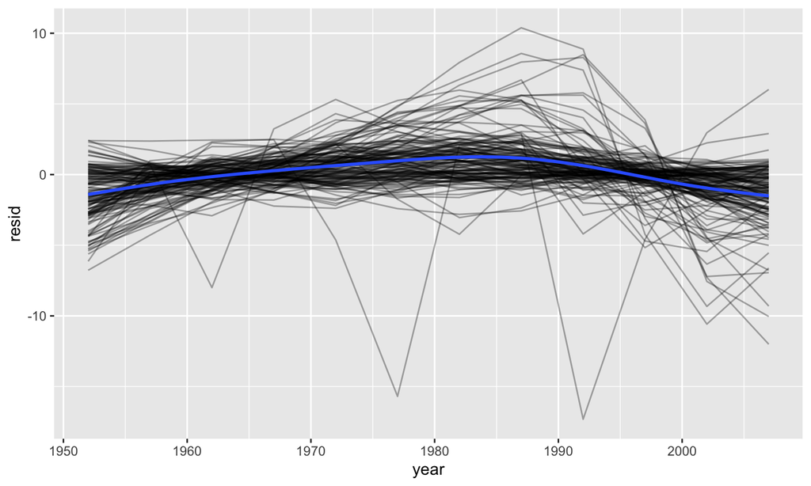

```r
resids %>%
  ggplot(aes(year, resid)) +
    geom_line(aes(group = country), alpha = 1 / 3) +
    geom_smooth(se = FALSE)
```

## Back to plotting

Facetting by continent is particularly revealing:

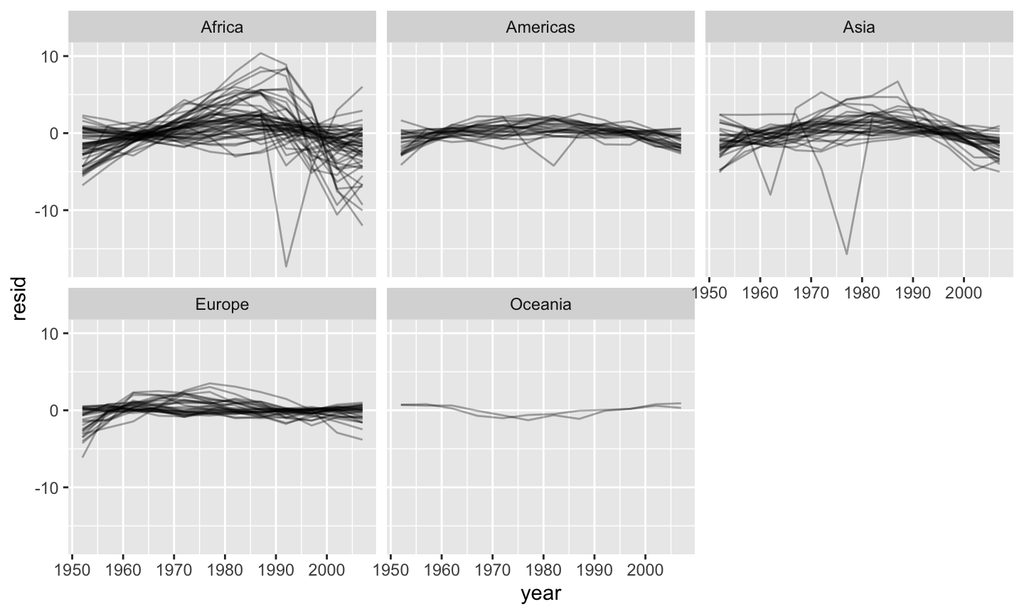

```r
resids %>%
  ggplot(aes(year, resid, group = country)) +
    geom_line(alpha = 1 / 3) +
    facet_wrap(~continent)
```

## broom: models to tidy data

```r
broom::glance(nz_mod)
```

```
## # A tibble: 1 x 11
##   r.squared adj.r.squared sigma statistic p.value    df logLik   AIC   BIC
##       <dbl>         <dbl> <dbl>     <dbl>   <dbl> <int>  <dbl> <dbl> <dbl>
## 1     0.954         0.949 0.804      205. 5.41e-8     2  -13.3  32.6  34.1
## # … with 2 more variables: deviance <dbl>, df.residual <int>
```

## broom: models to tidy data

```r
glance <- by_country %>%
  mutate(glance = map(model, broom::glance)) %>%
  unnest(glance)
```

## Looking for bad fit

```r
glance %>%
  arrange(r.squared)
```

```
## # A tibble: 142 x 16
## # Groups:   country, continent [710]
##    country continent     data model resids r.squared adj.r.squared sigma
##    <fct>   <fct>     <list<d> <lis> <list>     <dbl>         <dbl> <dbl>
##  1 Rwanda  Africa    [12 × 4] <lm>  <tibb…    0.0172      -0.0811   6.56
##  2 Botswa… Africa    [12 × 4] <lm>  <tibb…    0.0340      -0.0626   6.11
##  3 Zimbab… Africa    [12 × 4] <lm>  <tibb…    0.0562      -0.0381   7.21
##  4 Zambia  Africa    [12 × 4] <lm>  <tibb…    0.0598      -0.0342   4.53
##  5 Swazil… Africa    [12 × 4] <lm>  <tibb…    0.0682      -0.0250   6.64
##  6 Lesotho Africa    [12 × 4] <lm>  <tibb…    0.0849      -0.00666  5.93
##  7 Cote d… Africa    [12 × 4] <lm>  <tibb…    0.283        0.212    3.93
##  8 South … Africa    [12 × 4] <lm>  <tibb…    0.312        0.244    4.74
##  9 Uganda  Africa    [12 × 4] <lm>  <tibb…    0.342        0.276    3.19
## 10 Congo,… Africa    [12 × 4] <lm>  <tibb…    0.348        0.283    2.43
## # … with 132 more rows, and 8 more variables: statistic <dbl>,
## #   p.value <dbl>, df <int>, logLik <dbl>, AIC <dbl>, BIC <dbl>,
## #   deviance <dbl>, df.residual <int>
```

## Jitter

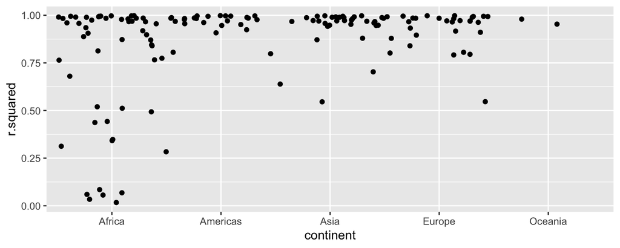

```r
glance %>%
  ggplot(aes(continent, r.squared)) +
    geom_jitter(width = 0.5)
```

## Bad fits

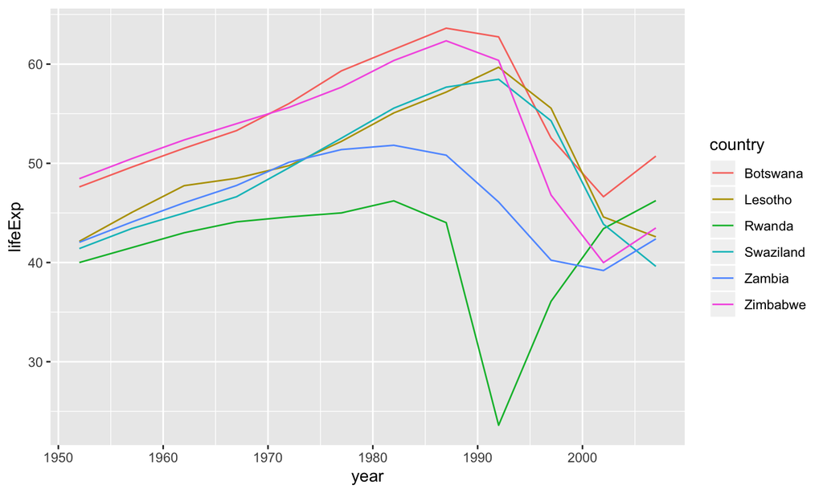

## Common broom functions

- `broom::glance(model)` returns a row for each model. Each column gives a model summary: either a measure of model quality, or complexity, or a combination of the two.
- `broom::tidy(model)` returns a row for each coefficient in the model. Each column gives information about the estimate or its variability.
- `broom::augment(model, data)` returns a row for each row in data, adding extra values like residuals, and influence statistics.